# Diversion in the Digital Age

How U.S. Politicians Portray Foreign Countries on Social Media During COVID-19

Selina Chu

2022-05-03

### Introduction

On April 14, 2022, amid a COVID outbreak in Shanghai, Chinese netizens protested on the Chinese social media platform Weibo. Satirically quoting from official presses, netizens posted tweets that pretended to criticize the US government but were actually complaining about the Chinese administration. Netizens ridiculed the government’s attempt to redirect the public’s attention from the Shanghai Omicron crisis and the government’s inadequate response to negative news about foreign countries.

However, the diversionary use of social media to redirect attention from domestic problems during COVID-19 has remained anecdotal. Research on diversionary practices has primarily focused on the use of military force to distract the public from domestic turmoil (Ostrom & Job, 1986; Miller, 1995; Mitchell & Prins, 2004). Additionally, COVID-19 presents not only a domestic challenge but also a global crisis. Previous research on politicians’ communication strategies has mostly analyzed speeches and interviews (Lasswell, 1948; Jagers & Walgrave, 2007; Jordan et al., 2019). The strategic use of social media has only recently attracted attention from academia.

Social media has played an increasingly active role in politics, and politicians around the world communicate on social media to affect public attitudes and behavior (Green et al., 2020; Barberá et al., 2021). There is research consensus that messages by political elites influence public opinions toward politicians’ success in office, public policies, and foreign affairs (Green et al., 2020; Drylie-Carey et al., 2020). Previous research on social media use by politicians has been limited to a few highly visible politicians like Donald Trump and certain types of leaders, such as populists and authoritarian statesmen (Lewandowsky et al., 2020; Aharony, 2012; Engesser et al., 2017; Bracciale & Martella, 2017; Zulianello et al., 2018; King et al., 2017; Roberts, 2018). Little research has investigated the diversionary use of social media during a crisis in democratic societies.

COVID-19 imposes the greatest public health and economic crisis in modern history. In 2020, the US had the fastest growth rate of cases among industrialized nations, and the economic activity reduction in the US has resulted in the highest unemployment rate since the Great Depression and the highest stock market volatility since the 2009 Financial Crisis (Green et al., 2020; Jiang et al., 2020). This project therefore fills a gap in politicians’ communication strategies in the digital age by investigating politicians’ diversionary use of social media during the COVID-19 Crisis. This research examines (1) the frequency that US politicians discuss foreign countries on Twitter, and (2) the sentiment in these tweets during COVID-19 relative to pre-COVID times. Additionally, this study will expand these two questions by exploring partisan differences in (3) the frequency of discussing foreign countries on Twitter, and (4) the sentiment in these tweets during COVID-19 compared to before.

### Existing Literature and Hypotheses

#### Diversionary Theory

Diversionary foreign policy is a political tool where governments interact with foreign entities to distract domestic population (Oakes, 2006; Ostrom & Job, 1986). Diversionary tactics are expected to (1) redirect the public’s attention from the source of complaint, and (2) boost support for the government by generating a rallying effect (Barberá et al., 2021; Sobek, 2007). Involvement in international conflicts can also create a scapegoating impact. United against a common foreign enemy, the public thereby overlooks internal divisions. Empirically, politicians have blamed domestic problems on foreign entities during times of mass internal complaints (Rozenas & Stukal, 2019; Götz, 2016).

The traditional diversionary theory focuses on the use of force abroad to distract the public from domestic unrest. For example, Turkey has used military intervention in Cyprus to strengthen national unity during a period of political fractionalization, radicalization, and extreme violence (Sirin, 2011). Several studies found that the US was more likely to take aggressive actions toward foreign countries during the Cold War when the president faced low levels of public support, partisan approval, and success in office (Ostom & Job, 1986; James & Oneal, 1991; Morgan & Bickers, 1992; James & Hristoulas, 1994). Similarly, the probability of threat, display, and use of force by the UK is inversely related to support for the prime minister’s party (Morgan & Anderson, 1999). In a study that analyzed data from more than 139 countries over 87 years, Sirin (2011) discovered that countries are significantly more likely to use force in an international crisis when there are increasing levels of mass domestic violence.

Recent research on diversionary theory has expanded to tactics alternative to the use of force. Collecting data from over 190 countries, Amarasinghe (2022) provided evidence of the systematic use of verbal aggression towards foreign entities as a short-term, low-cost, and low-risk strategy to divert attention from domestic turmoil. Rozenas and Stukal (2019) suggested that Russian leaders have systematically attributed bad domestic news to external factors, especially during politically sensitive times, such as during elections and protests. Alrababa’h and Blaydes (2021) found that during the Arab Spring in 2011, Syrian state-backed outlets blamed foreign conspiracies against the Syrian government for the country’s problems to strengthen nationalism and unity.

The diversionary use of social media has only recently attracted attention in the academic field. Results indicate that states have strategically used social media to divert public attention and change the subject, but research has been limited to non-democratic regimes and a few pronounced politicians. For example, King and colleagues (2017) found that China recruited pro-government commentators to send cheerleading social media posts to distract the public from general negativity and events with protest potential. According to Lewandowsky and colleagues (2020), Trump systematically used Twitter to divert media attention from news that is politically harmful to him. Taking the Mueller investigation as an example, the researchers identified an immediate increase in Trump’s tweeting activities about unrelated issues. Following this heightened activity, the media reduced coverage of the Mueller investigation. This pattern is absent in placebo issues like Brexit that did not threaten Trump’s political status.

COVID-19 presents significant public health and economic crisis and thus might incentivize politicians to adopt diversionary practices. Limited research has studied the strategic use of social media by politicians during COVID-19. During COVID-19, China, Iran, Russia, and Turkey used state-backed media on Facebook and Twitter to transmit political narratives and influence foreign public opinion (Rebello et al., 2020; Bright et al., 2020). Results convey that these countries have strategically used social media to spread certain political messages during COVID-19 to undermine their rivals and promote their positive or leadership image. Together, the diversionary theory and the scapegoating effect of diversionary practices lead to the first three hypotheses:

*Hypothesis 1: Politicians in the US tweet about foreign countries more frequently during COVID-19 than before COVID-19.*  
*Hypothesis 2a: Politicians in the US tweet about foreign countries less positively during COVID-19 than before COVID-19.*  
*Hypothesis 2b: Politicians in the US tweet about foreign countries more negatively during COVID-19 than before COVID-19.*

#### Partisan Divisions on Social Media During COVID-19

Research has documented partisan divisions in messages about COVID-19 on social media. Analyzing tweets related to COVID-19 in the US between January and April 2020, Jiang and colleagues (2020) found a partisan split in attitudes toward the COVID-19 responses by the Trump administration. The top hashtags in Democratic-leaning states were primarily critical of the federal administration, whereas the top hashtags in Republican-leaning states mostly generated presidential support. Focusing on tweets by congress members, Green and colleagues (2020) discovered polarized communication among political elites as well. Whereas Democrats focused more on the pandemic itself – its impact on public health and American workers – Republicans tended to discuss China and businesses. As the then incumbent administration, Republicans may have greater incentives to divert attention from domestic turmoil to foreign news. On the other hand, Democrats may have greater incentives to emphasize Republicans’ failed policies. This reasoning leads to the third and fourth hypotheses:

*Hypothesis 3: Republicans tweet about foreign countries more frequently than Democrats during COVID-19 relative to before COVID-19.*  
*Hypothesis 4a: Republicans tweet about foreign countries less positively than Democrats during COVID-19 relative to before COVID-19.*  
*Hypothesis 4b: Republicans tweet about foreign countries more negatively than Democrats during COVID-19 relative to before COVID-19.*

### Methods

#### Data Collection and Cleaning

With the appearance of Donald Trump, Twitter has been elevated to the center in US politics (Lewandowsky et al., 2020). Congress members frequently convey their political opinions and communicate with voters on Twitter (Green et al., 2020). Based on these reasons, this study investigates how politicians discuss foreign countries during COVID-19 via Twitter. Tweets posted in office by members who served on both the 115th and 116th Congress (2017-2021) are collected to control for individual differences.

This study collects the tweets via the Twitter API (Twitter, n.d.). Using datasets of status ids, this project acquires all 2,041,399 tweets by the 115th Congress posted before January 2, 2019, and all 2,817,747 tweets by the 116th Congress posted before May 7, 2020 (Wrubel & Kerchner, 2020; Littman, 2017). Since some Tweets and Twitter accounts have been deleted, only 65.2% of the tweets by the 115th Congress and 59.5% of the tweets by the 116th Congress are retrievable. Tweets by the 116th Congress between May 8, 2020, and January 3, 2021, are manually collected via the Twitter API, which includes 235,525 tweets (Twitter, n.d.). Filtering for tweets posted in-office generates 543,066 and 821,310 tweets by the 115th and 116th Congress, respectively.

This research then retrieves all Twitter handles and user ids of the 115th and 116th Congress (Wrubel & Kerchner, 2020; Littman, 2017; Siddique, 2019). This information is merged with biographical information of the members, including birth date, gender, and party affiliation (Isacson, 2019; Tucker, 2017). After manual screening, this generates a profile dataset that includes information of all members of both the 115th and 116th Congress. The acquired tweets are merged with the profile dataset, which returns a total of 1,071,245 tweets by 428 congress members.

Stop words and URLs are removed from the texts. The tweets are identified as whether posted during COVID (after January 20, 2020, when the first COVID case was detected in the US) or pre-COVID (Centers for Disease Control and Prevention, 2022).

#### Foreign Tweets

Foreign tweets are tweets that talk about a foreign country. This study builds on geographical text analysis (GTA) to identify foreign tweets. GTA is a method to analyze place names in texts and their meanings by converting texts into a geographical information system. The conversion requires three stages: (1) identifying place names, (2) inserting a coordinate or spatial representation of these places, and (3) converting co-text into tabular form (Paterson & Gregory, 2019). Since this research does not include a spatial component, only place names and the co-texts are relevant. Place names in texts can refer to an environment or the type of people who live there (Paterson & Gregory, 2019). In international news, place names can construct the entire geographical area (such as a country) as a uniform whole, and its population is assumed to hold the same social values, economic status, and/or political beliefs (Paterson & Gregory, 2019). The homogenizing function of mentioning place names may be used to achieve diversionary goals, such as creating a foreign enemy. Therefore, this project identifies a foreign tweet as a tweet that mentions the name of a foreign country or one of its common variants (Schiff, 2015). To better identify countries mentioned in tweets, all texts are coerced to lower case.

Notably, the geotagging process of identifying place names is subject to ambiguous names. Some place names can refer to the place, a person, or other features. Place names can also refer to multiple places. To avoid such errors, ambiguous country names like Georgia, Jersey, and CAR (Central African Republic) are filtered out and not identified. Since these names are more likely to refer to American states or something that is not a country, and variants of their names are still identified, this should not create concern with the analysis.

#### Sentiment Analysis

This project uses the sentiment lexicon developed by Hu and Liu (2004), or the Bing dictionary, to measure the sentiment in tweets. The dictionary is available in the tidytext R package (Silge & Robinson, 2016). To prevent positive and negative words from canceling out each other in a highly emotional tweet, these two sentiments in each tweet are calculated separately. The positive and negative score of each tweet is calculated as the percentage of positive and negative words out of the total number of words in each tweet:

Positive score = N(positive) / N(total words)  
Negative score = N(negative) / N(total words)

#### Regression Models

To control for demographic factors, this research uses linear regression models to test the six hypotheses. Variables in the models are defined as follows:

`is_foreign`: Takes a value of 1 if tweet *i* is classified as a foreign tweet, and 0 otherwise.  
`is_covid`: Takes a value of 1 if tweet *i* is posted during COVID, and 0 otherwise.  
`independent`: Takes a value of 1 if the politician who posted tweet *i* is an Independent, and 0 otherwise.  
`republican`: Takes a value of 1 if the politician who posted tweet *i* is a Republican, and 0 otherwise.  
`male`: Takes a value of 1 if the politician who posted tweet *i* is male, and 0 otherwise.  
`age`: Current age of the politician who posted tweet *i*.  
`positive_score`: The positive score of tweet *i*.  
`negative_score`: The negative score of tweet *i*.

**Model 1:** $is\_foreign_i = \alpha_0 + \alpha_1\,is\_covid_i + \alpha_2\,independent_i + \alpha_3\,republican_i + \alpha_4\,male_i + \alpha_5\,age_i + u_i$

Since only the sentiment in foreign tweets is relevant, Model 2a and 2b run the regression within the subset of foreign tweets.

**Model 2a:** $positive\_score_i = \beta_0 + \beta_1\,is\_covid_i + \beta_2\,independent_i + \beta_3\,republican_i + \beta_4\,male_i + \beta_5\,age_i + u_i$

**Model 2b:** $negative\_score_i = \gamma_0 + \gamma_1\,is\_covid_i + \gamma_2\,independent_i + \gamma_3\,republican_i + \gamma_4\,male_i + \gamma_5\,age_i + u_i$

To explore partisan differences in the proportion of foreign tweets before and during COVID, Model 3 to 4b uses the difference-in-difference method by adding an interaction term of `is_covid` and `independent` and `republican` to the corresponding models above.

**Model 3:** $is\_foreign_i = \delta_0 + \delta_1\,is\_covid_i + \delta_2\,independent_i + \delta_3\,republican_i + \delta_4\,is\_covid_i \times independent_i + \delta_5\,is\_covid_i \times republican_i + \delta_6\,male_i + \delta_7\,age_i + u_i$  
As the hypothesis focuses on the difference in frequency of posting foreign tweets between Republicans and Democrats during COVID compared to pre-COVID, $\delta_5$ is the coefficient of interest.

Since only the sentiment in foreign tweets is relevant, Model 4a and 4b run the regression within the subset of foreign tweets.

**Model 4a:** $positive\_score_i = \zeta_0 + \zeta_1\,is\_covid_i + \zeta_2\,independent_i + \zeta_3\,republican_i + \zeta_4\,is\_covid_i \times independent_i + \zeta_5\,is\_covid_i \times republican_i + \zeta_6\,male_i + \zeta_7\,age_i + u_i$  
Like Model 3, $\zeta_5$ is the coefficient of interest.

**Model 4b:** $negative\_score_i = \eta_0 + \eta_1\,is\_covid_i + \eta_2\,independent_i + \eta_3\,republican_i + \eta_4\,is\_covid_i \times independent_i + \eta_5\,is\_covid_i \times republican_i + \eta_6\,male_i + \eta_7\,age_i + u_i$  
Similarly, $\eta_5$ is the coefficient of interest.

### Data Overview

The general corpus is composed of 1,071,245 tweets by 428 congress members posted between January 3, 2017, and January 3, 2021. Of these tweets, 32.7% were posted during COVID, and 4.56% are identified as foreign tweets.

Figures 1 and 2 exhibit the composition of the general corpus by parties. Notably, the general corpus is posted overwhelmingly by Democrats. Both before and during COVID, Democrats posted around 2/3 of the tweets, and Republicans posted around 1/3. This provides another reason to explore the research questions by parties, as the general corpus can be biased towards Democrats.

Figure 1

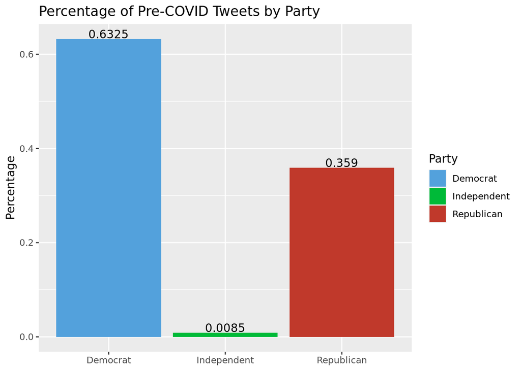

Figure 2

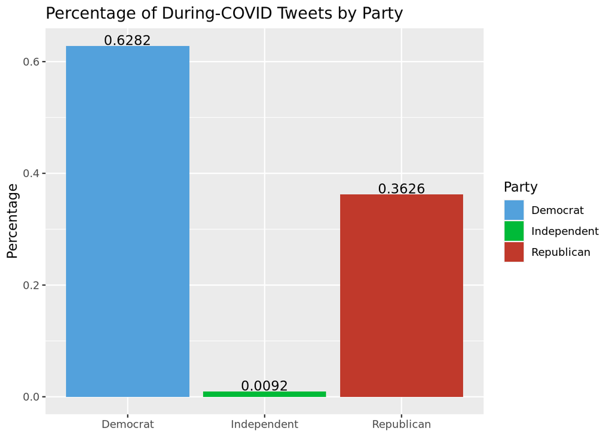

Republicans are more likely than Democrats to post foreign tweets. Table 1 presents the proportion of foreign tweets out of total tweets by parties. Results suggest that Republicans have the highest percentage of foreign tweets (5.93%), and Democrats have the lowest (3.78%).

Table 1

| party | percent_foreign |
| --- | --- |
| Democrat | 0.0378152 |
| Independent | 0.0444681 |
| Republican | 0.0592726 |

Democrats and Republicans also differ in preferences for the foreign countries they discussed. Figure 3 shows the ten most frequently mentioned countries by each party. Each party’s top country was mentioned much more often than others. Republicans mostly focused on China, which shows up in over 20% of their foreign tweets. Although Democrats also placed a heavy focus on China, which is ranked the second, the percentage is much lower (around 7%). Instead, Democrats’ top focus is Mexico, mentioning the country in around 12.5% of their foreign tweets.

Figure 3

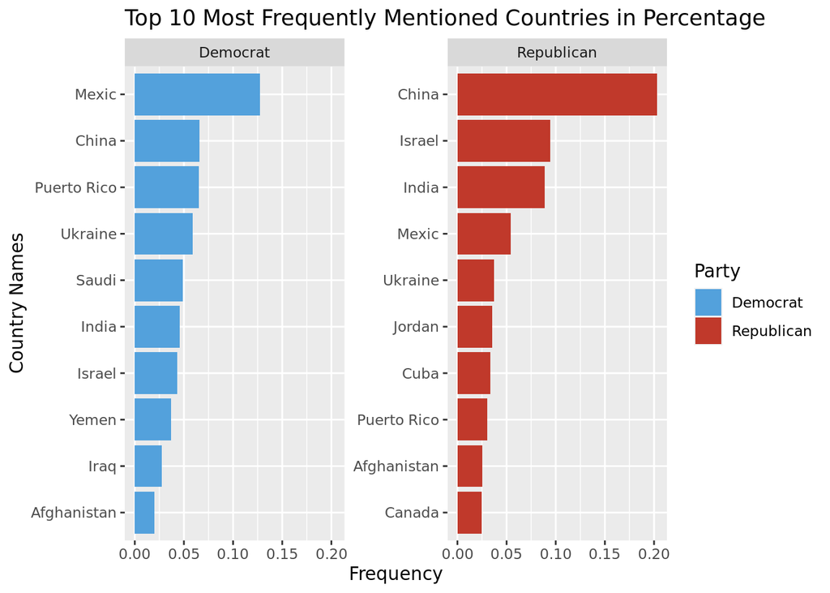

### Results

#### Hypothesis 1

Figure 4 plots the average proportion of foreign tweets by month from January 2017 to January 2021. A higher proportion would indicate more attention paid to foreign countries. The scatterplot exhibits a surprisingly clear trend: the proportion of foreign tweets continued to increase and peaked at the end of 2019, right before the onset of COVID. The proportion of foreign tweets then gradually declined as COVID worsened.

Figure 4

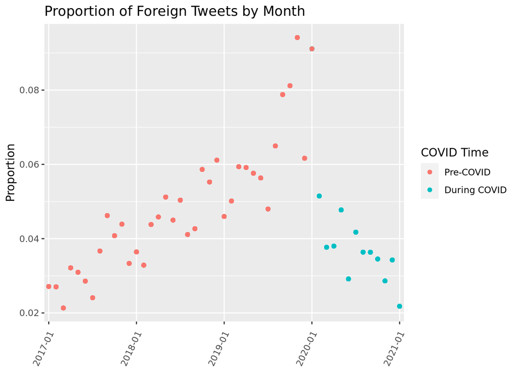

Table 2 presents the regression results of Model 1, and Figure 5 plots the size of COVID’s effect on posting foreign tweets. Concurring the descriptive statistics, tweets posted during COVID are significantly less likely to talk about a foreign country (p-value < 0.001). The proportion of foreign tweets posted during COVID is on average 1.03 percentage points lower than the proportion pre-COVID. Although this is a small number, given the small proportion of foreign tweets in the general corpus, a 1.03 percentage-point difference is quite large. Therefore, Hypothesis 1 is rejected.

Table 2: Regression Results of Model 1

```
##
## Call:
## lm(formula = is_foreign ~ is_covid + party + gender + age, data = tweets)
##
## Residuals:
##      Min       1Q   Median       3Q      Max
## -0.08100 -0.05630 -0.04308 -0.03252  0.99247
##
## Coefficients:
##                     Estimate  Std. Error t value             Pr(>|t|)
## (Intercept)       0.08317997  0.00131073  63.461 < 0.0000000000000002 ***
## is_covid         -0.01030268  0.00042858 -24.039 < 0.0000000000000002 ***
## partyIndependent  0.01484640  0.00218929   6.781      0.0000000000119 ***
## partyRepublican   0.01663223  0.00044047  37.760 < 0.0000000000000002 ***
## genderMale        0.00909138  0.00047148  19.283 < 0.0000000000000002 ***
## age              -0.00073419  0.00001883 -38.984 < 0.0000000000000002 ***
## ---
## Signif. codes:  0 '***' 0.001 '**' 0.01 '*' 0.05 '.' 0.1 ' ' 1
##
## Residual standard error: 0.2081 on 1071239 degrees of freedom
## Multiple R-squared:  0.00484,    Adjusted R-squared:  0.004836
## F-statistic:  1042 on 5 and 1071239 DF,  p-value: < 0.00000000000000022
```

Figure 5

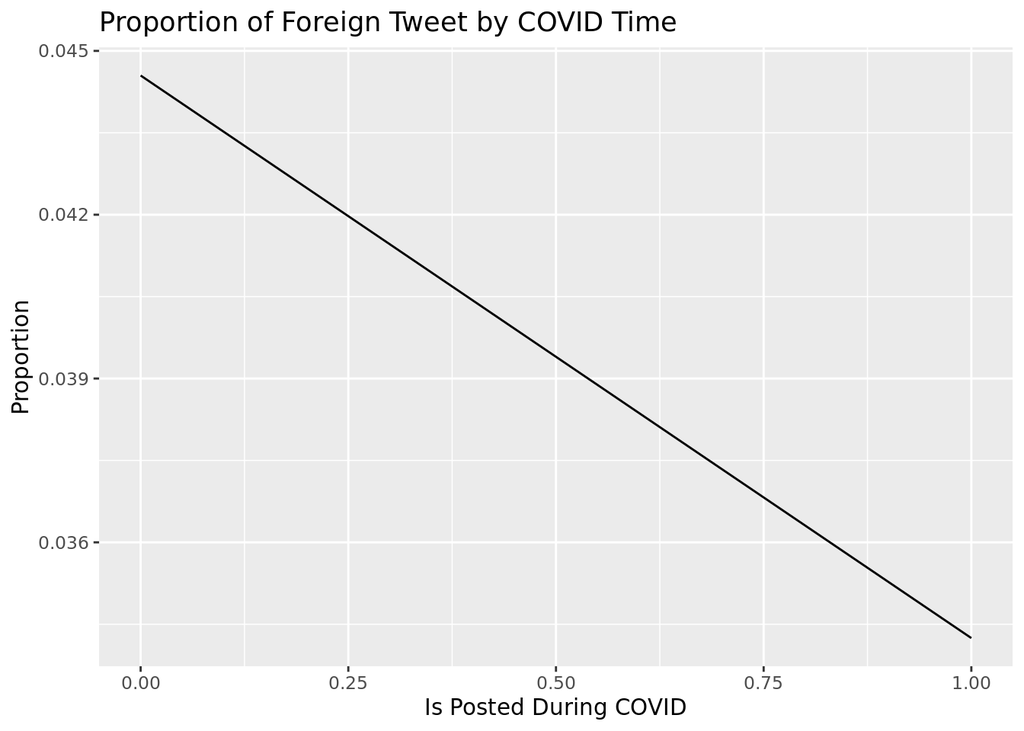

#### Hypothesis 2

Figure 6 plots the three-month average sentiment scores of foreign tweets from January 2017 to January 2021. The blue vertical line divides pre-COVID and during-COVID tweets. The positive score fluctuated before COVID but rapidly increased during COVID. The negative score increased in 2018 and then decreased during the first half of 2019, after which it rebounded. However, the negative score quickly dropped shortly after the outbreak of COVID-19.

Figure 6

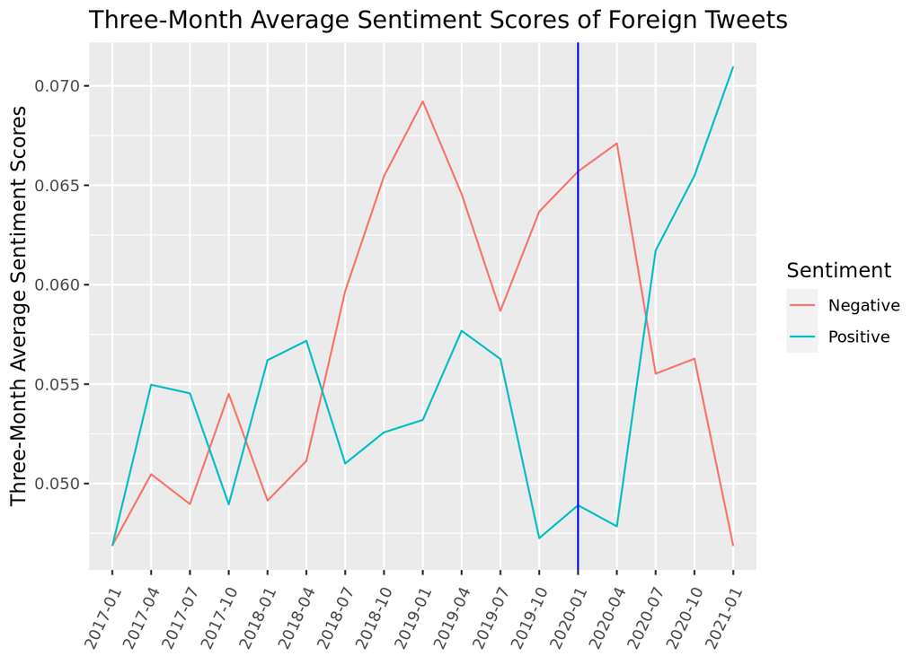

#### Hypothesis 2a

As shown in Table 3, Model 2a’s results confirm the trends in Figure 6. Foreign tweets posted during COVID are significantly more positive than those posted before COVID (p-value < 0.001). The positive scores of foreign tweets during COVID are on average 0.0046 higher than the positive scores of pre-COVID foreign tweets. Figure 7 plots the size of `is_covid`’s effect on the positive scores of foreign tweets, and the line graph shows a positive trend from pre- to during COVID. These results reject Hypothesis 2a.

Table 3: Regression Results of Model 2a

```
##
## Call:
## lm(formula = positive_score_2 ~ is_covid + party + gender + age,
##     data = tweets, subset = is_foreign == 1)
##
## Residuals:
##      Min       1Q   Median       3Q      Max
## -0.05987 -0.05315 -0.01288  0.03713  0.94736
##
## Coefficients:
##                     Estimate  Std. Error t value             Pr(>|t|)
## (Intercept)       0.04861272  0.00195530  24.862 < 0.0000000000000002 ***
## is_covid          0.00455426  0.00069228   6.579      0.0000000000479 ***
## partyIndependent -0.00832893  0.00340010  -2.450              0.01430 *
## partyRepublican   0.00174033  0.00064389   2.703              0.00688 **
## genderMale       -0.00010955  0.00078083  -0.140              0.88842
## age               0.00005700  0.00002802   2.034              0.04195 *
## ---
## Signif. codes:  0 '***' 0.001 '**' 0.01 '*' 0.05 '.' 0.1 ' ' 1
##
## Residual standard error: 0.06807 on 48844 degrees of freedom
## Multiple R-squared:  0.0013, Adjusted R-squared:  0.001198
## F-statistic: 12.71 on 5 and 48844 DF,  p-value: 0.000000000002256
```

Figure 7

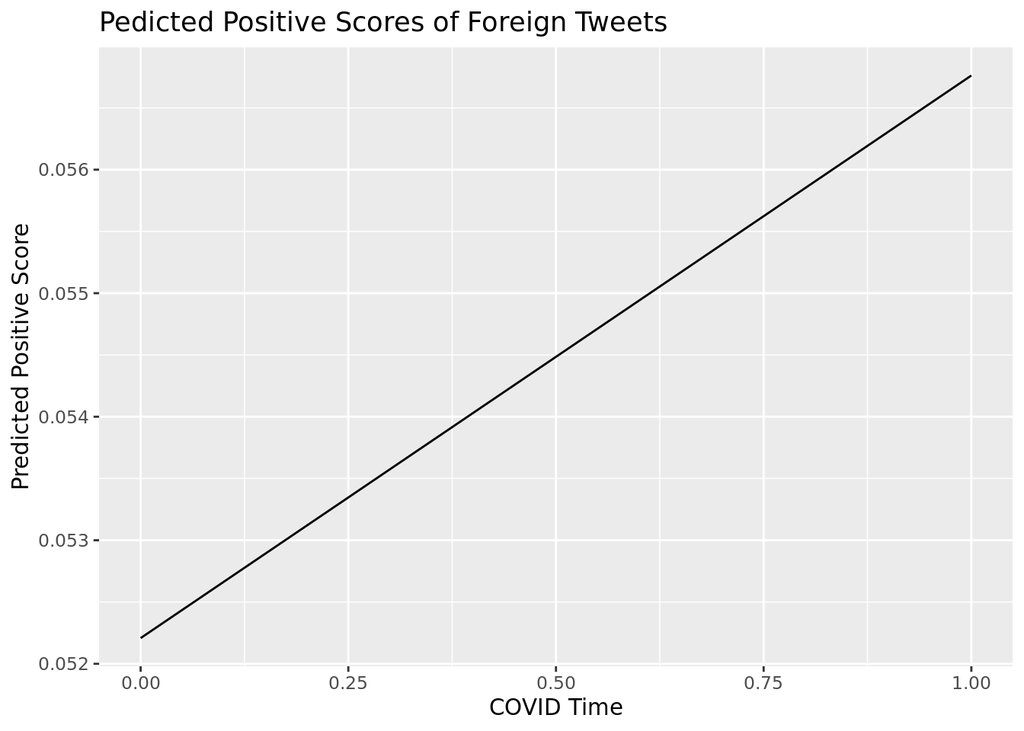

#### Hypothesis 2b

Table 4: Regression Results of Model 2b

```
##
## Call:
## lm(formula = negative_score_2 ~ is_covid + party + gender + age,
##     data = tweets, subset = is_foreign == 1)
##
## Residuals:
##      Min       1Q   Median       3Q      Max
## -0.08726 -0.05581 -0.02186  0.04022  0.93025
##
## Coefficients:
##                     Estimate  Std. Error t value             Pr(>|t|)
## (Intercept)       0.04767049  0.00215066  22.166 < 0.0000000000000002 ***
## is_covid          0.00256397  0.00076144   3.367             0.000760 ***
## partyIndependent  0.01340254  0.00373981   3.584             0.000339 ***
## partyRepublican  -0.01494915  0.00070822 -21.108 < 0.0000000000000002 ***
## genderMale        0.00569768  0.00085884   6.634    0.000000000032983 ***
## age               0.00022135  0.00003082   7.182    0.000000000000696 ***
## ---
## Signif. codes:  0 '***' 0.001 '**' 0.01 '*' 0.05 '.' 0.1 ' ' 1
##
## Residual standard error: 0.07487 on 48844 degrees of freedom
## Multiple R-squared:  0.01261,    Adjusted R-squared:  0.01251
## F-statistic: 124.7 on 5 and 48844 DF,  p-value: < 0.00000000000000022
```

Figure 8

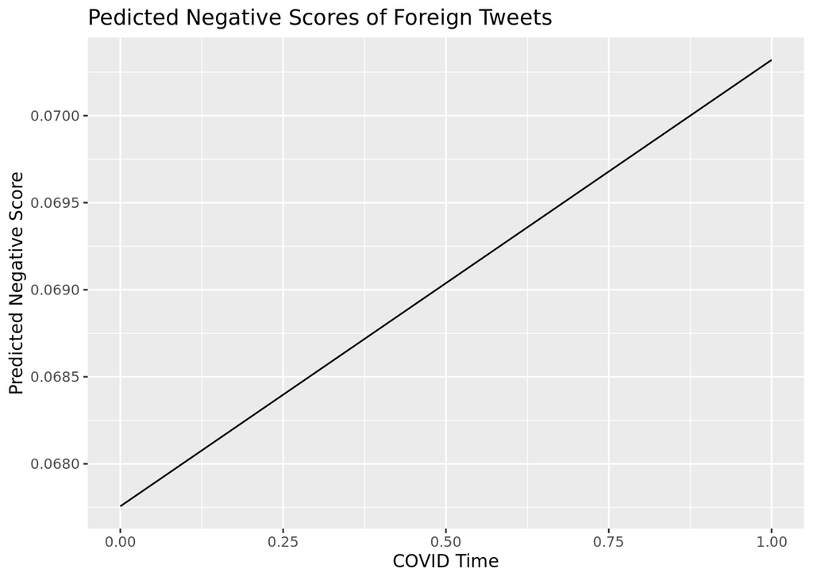

#### Hypothesis 3

Figure 9

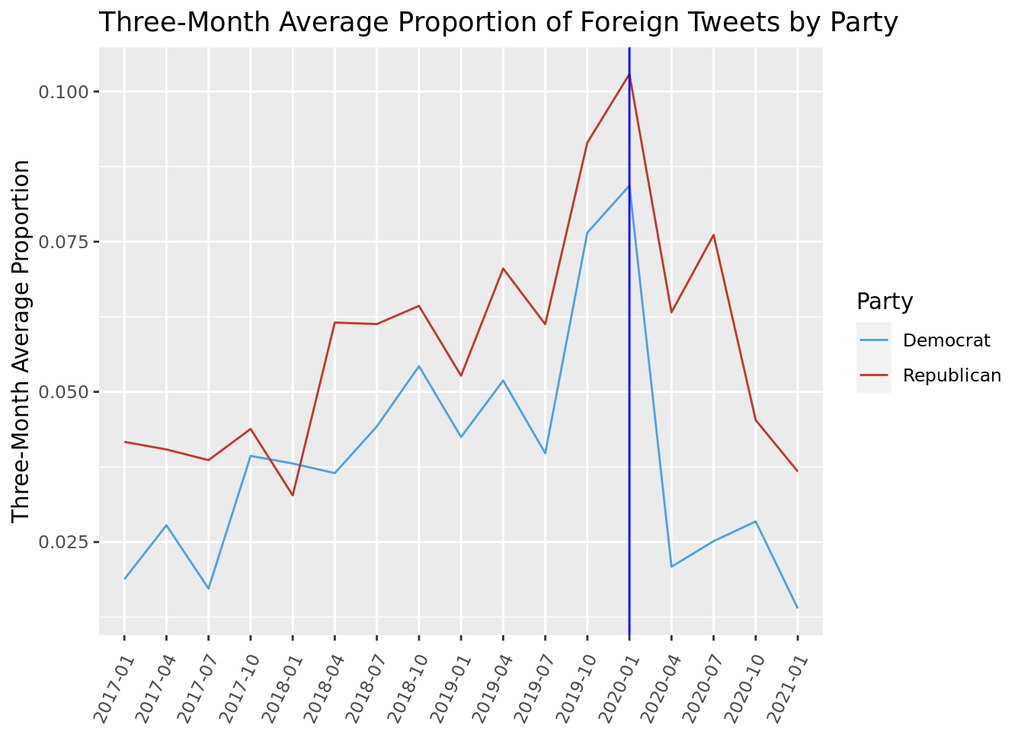

Model 3’s results in Table 5 support Hypothesis 3. Looking at $\hat{\delta}_5$, Republicans at least decreased their attention to foreign countries less than Democrats during COVID than pre-COVID. This difference is significant (p-value < 0.01) and is visualized in Figure 10. As shown by the line graph, the partisan difference in the proportion of foreign tweets enlarged after COVID’s outbreak. In fact, Republicans slightly increased mentioning foreign countries, while Democrats sharply decreased their mention of foreign countries.

Table 5: Regression Results of Model 3

```
##
## Call:
## lm(formula = is_foreign ~ is_covid + party + is_covid * party +
##     gender + age, data = tweets)
##
## Residuals:
##      Min       1Q   Median       3Q      Max
## -0.07811 -0.05653 -0.04423 -0.03215  0.99667
##
## Coefficients:
##                              Estimate  Std. Error t value             Pr(>|t|)
## (Intercept)                0.08573121  0.00131809  65.042 < 0.0000000000000002
## is_covid                  -0.01617178  0.00054003 -29.946 < 0.0000000000000002
## partyIndependent           0.01957647  0.00269101   7.275    0.000000000000347
## partyRepublican            0.01115842  0.00053033  21.041 < 0.0000000000000002
## genderMale                 0.00910124  0.00047140  19.307 < 0.0000000000000002
## age                       -0.00074412  0.00001884 -39.502 < 0.0000000000000002
## is_covid:partyIndependent -0.01297717  0.00454857  -2.853              0.00433
## is_covid:partyRepublican   0.01657032  0.00089459  18.523 < 0.0000000000000002
##
## (Intercept)               ***
## is_covid                  ***
## partyIndependent          ***
## partyRepublican           ***
## genderMale                ***
## age                       ***
## is_covid:partyIndependent **
## is_covid:partyRepublican  ***
## ---
## Signif. codes:  0 '***' 0.001 '**' 0.01 '*' 0.05 '.' 0.1 ' ' 1
##
## Residual standard error: 0.2081 on 1071237 degrees of freedom
## Multiple R-squared:  0.005175,   Adjusted R-squared:  0.005169
## F-statistic: 796.1 on 7 and 1071237 DF,  p-value: < 0.00000000000000022
```

Figure 10

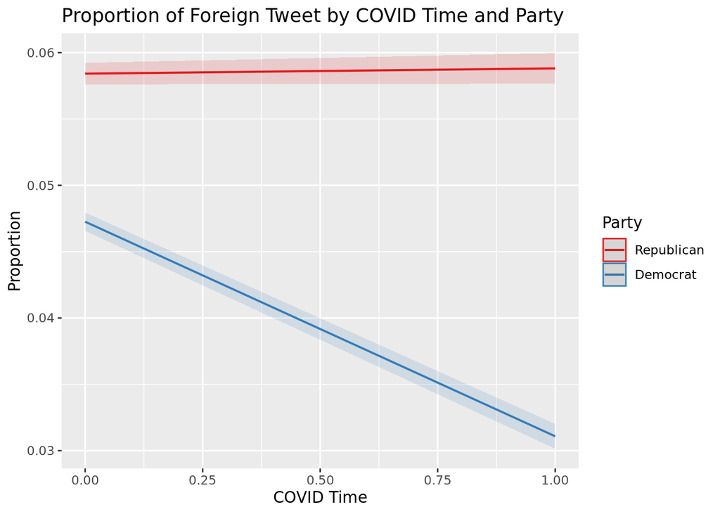

#### Hypothesis 4

Figure 11 presents the three-month average sentiment scores of foreign tweets by party, separated by COVID time. The positive scores of both parties fluctuate and are largely similar. During COVID, Republicans’ positive scores first increased during the first half of 2020, after which they continued to decline. On the other hand, Democrats’ positive scores consistently climbed up during COVID and sharply increased during the last quarter of 2020.

Looking at negative scores, Democrats were consistently more critical of foreign countries than Republicans, but the negativity of both parties declined during COVID. Specifically, Republicans’ negativity toward foreign countries first increased during the first quarter of 2020, and then gradually declined. On the other hand, Democrats’ negative scores dropped sharply during COVID. In fact, Republicans were more negative toward foreign countries than Democrats in January 2021, for the first time since January 2017.

Figure 11

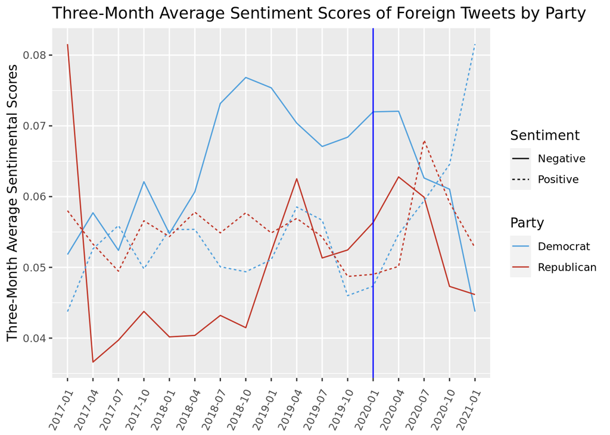

#### Hypothesis 4a

Model 4a’s results suggest that Republicans boosted their positivity toward foreign countries significantly less than Democrats during COVID than before (p-value < 0.05). Figure 12 illustrates the size of this before-after difference. Although both parties became more positive toward foreign countries during COVID, the size of the increase is greater for Democrats than Republicans. Before COVID, Republicans were more positive toward foreign countries than Democrats, but this relationship was reversed during COVID. Thus, the results fail to reject Hypothesis 4a.

Table 6: Regression Results of Model 4a

```
##
## Call:
## lm(formula = positive_score_2 ~ is_covid + party + is_covid *
##     party + gender + age, data = tweets, subset = is_foreign ==
##     1)
##
## Residuals:
##      Min       1Q   Median       3Q      Max
## -0.05965 -0.05346 -0.01304  0.03676  0.94689
##
## Coefficients:
##                              Estimate  Std. Error t value             Pr(>|t|)
## (Intercept)                0.04798319  0.00197316  24.318 < 0.0000000000000002
## is_covid                   0.00627191  0.00100778   6.223        0.00000000049
## partyIndependent          -0.00894756  0.00378325  -2.365             0.018032
## partyRepublican            0.00268865  0.00075492   3.561             0.000369
## genderMale                -0.00011418  0.00078080  -0.146             0.883733
## age                        0.00006066  0.00002806   2.162             0.030639
## is_covid:partyIndependent  0.00315902  0.00844383   0.374             0.708316
## is_covid:partyRepublican  -0.00334013  0.00139272  -2.398             0.016476
##
## (Intercept)               ***
## is_covid                  ***
## partyIndependent          *
## partyRepublican           ***
## genderMale
## age                       *
## is_covid:partyIndependent
## is_covid:partyRepublican  *
## ---
## Signif. codes:  0 '***' 0.001 '**' 0.01 '*' 0.05 '.' 0.1 ' ' 1
##
## Residual standard error: 0.06806 on 48842 degrees of freedom
## Multiple R-squared:  0.001424,   Adjusted R-squared:  0.001281
## F-statistic: 9.953 on 7 and 48842 DF,  p-value: 0.000000000001758
```

Figure 12

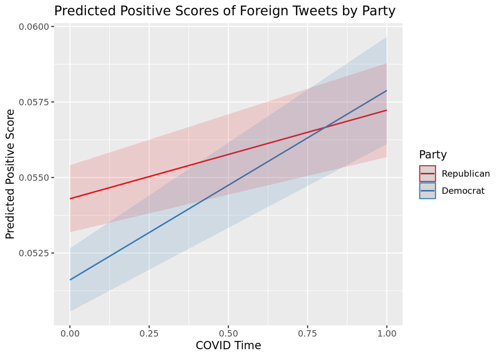

#### Hypothesis 4b

As shown in Table 7, Model 4b’s results accord with Hypothesis 4b. Looking at $\hat{\eta}_5$, Republicans at least reduced their negativity toward foreign countries less than Democrats during COVID. This partisan difference is significant (p-value < 0.001). Figure 13 further clarifies the results by plotting the change in partisan differences in negative scores before and during COVID. The graph illustrates that the partisan difference narrowed during COVID. In fact, while Democrats became less negative toward foreign countries, Republicans became much more negative.

Table 7: Regression Results of Model 4b

```
##
## Call:
## lm(formula = negative_score_2 ~ is_covid + party + is_covid *
##     party + gender + age, data = tweets, subset = is_foreign ==
##     1)
##
## Residuals:
##      Min       1Q   Median       3Q      Max
## -0.08933 -0.05800 -0.02153  0.04020  0.92940
##
## Coefficients:
##                              Estimate  Std. Error t value             Pr(>|t|)
## (Intercept)                0.04916773  0.00216968  22.661 < 0.0000000000000002
## is_covid                  -0.00148317  0.00110816  -1.338               0.1808
## partyIndependent           0.01723646  0.00416006   4.143     0.00003428930546
## partyRepublican           -0.01723615  0.00083011 -20.764 < 0.0000000000000002
## genderMale                 0.00570722  0.00085857   6.647     0.00000000003015
## age                        0.00021252  0.00003086   6.887     0.00000000000575
## is_covid:partyIndependent -0.01953665  0.00928483  -2.104               0.0354
## is_covid:partyRepublican   0.00802838  0.00153143   5.242     0.00000015916370
##
## (Intercept)               ***
## is_covid
## partyIndependent          ***
## partyRepublican           ***
## genderMale                ***
## age                       ***
## is_covid:partyIndependent *
## is_covid:partyRepublican  ***
## ---
## Signif. codes:  0 '***' 0.001 '**' 0.01 '*' 0.05 '.' 0.1 ' ' 1
##
## Residual standard error: 0.07484 on 48842 degrees of freedom
## Multiple R-squared:  0.0133, Adjusted R-squared:  0.01316
## F-statistic: 94.03 on 7 and 48842 DF,  p-value: < 0.00000000000000022
```

Figure 13

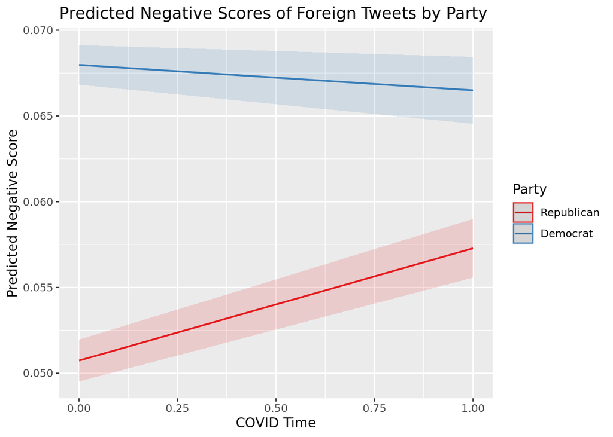

### Discussion

Examining foreign tweets by parties provides some insights into this issue. It is clear that Model 1’s results are driven by Democrats’ reduced attention and negativity toward foreign countries. Republicans became both more attentive and more negative toward foreign countries during COVID, whereas Democrats became less attentive and less negative. While both parties became more positive toward foreign countries, the size of the increase for Republicans is significantly smaller than that for Democrats.

A potential explanation for these partisan differences is the growing anti-China sentiment in American politics, which surged during the Trump administration (Zaidi & Saud, 2020; Sutter, 2017). Green and colleagues (2020) found that Republicans tend to focus on China and businesses in their discourse about COVID-19. Figure 14 exhibits the ten most frequently mentioned foreign countries by party and COVID time. Republicans sharply heightened their attention to China during COVID from over 10% of their foreign tweets to nearly 40%. In fact, three out of the ten most frequently mentioned country names by Republicans during COVID are related to China (China, Hong Kong, and HongKong). This trend is absent among Democrats and other countries. Therefore, it is possible that Republicans’ lessened positivity and strengthened negativity compared to Democrats is based on the anti-China rhetoric.

Figure 14

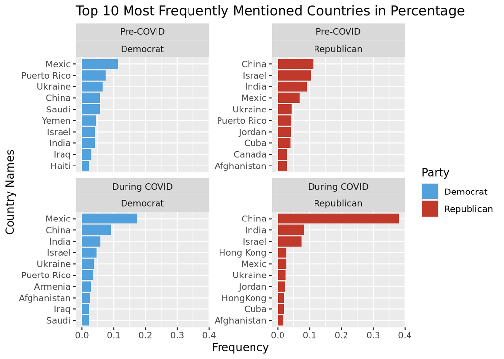

This project lays groundwork for examining diversionary theory in the digital age. While results fail to support the adoption of diversionary tactics by politicians overall, partisan differences provide evidence of diversionary practices by the then incumbent party. The partisan difference could be explained by the anti-China sentiment. Although it is possible that this is based on previous rhetoric, it is also possible that Republicans have been using China to generate a scapegoating effect, as suggested by the diversionary theory (Rozenas & Stukal, 2019; Götz, 2016). Future research can further investigate factors that influence parties’ sentiment toward different countries on social media.

### Limitations and Future Work

Although this research helps understand politicians’ diversionary strategies on social media, it has several limitations. This paper only investigates politicians’ messages on Twitter, which can return biased results if politicians systematically adopt a communication strategy specific to Twitter. As stated above, the general corpus is biased towards Democrats’ tweets. A better approach might be to extract a random sample from the general corpus that is composed of the same number of tweets by each party. Additionally, only about 60% of the tweets by the 115th and 116th Congress are retrievable as of this writing. Some politicians deleted their official Twitter accounts after resigning from office or losing re-elections, and some deleted their accounts after media backlash. For example, Jeff Van Drew and Chris Smith, two Republican congressmen, deleted their Twitter accounts following backlash allegedly due to their pro-Trump stance (Friedman, 2021). If tweet deletion is not random, the regression results can be biased.

Furthermore, the geotagging process is also prone to errors like ambiguous country names and incomplete name list. Scholars have used machine learning techniques to address this problem, which may be a future research direction (Barberá et al., 2021).

It is also important to note that the sentiment analysis is subject to false association errors. The sentiment token might not be related to the foreign country mentioned, or the politician may be using satire. Researchers have dealt with false association by manually checking all extracted texts, but this is beyond the scope of this paper (Paterson, 2020; Paterson & Gregory, 2019). Furthermore, the sentiment dictionary used is not customized to political texts. For example, the Bing dictionary classifies “trump” as a positive word, which is not suitable in the political context (Hu & Liu, 2004). Also, the binary classification of sentiment fails to capture the intensity of sentiment and can be arbitrary. Future studies can conduct more thorough coding of the tweets and experiment with natural language processing to increase the accuracy of sentiment interpretation and categorization.

The limitations above suggest the need for further research to explore the strategic use of social media by politicians. Future studies can expand to other social media platforms like Facebook, GETTR, and the newly launched Truth Social to gather a more comprehensive sample of social media posts. Additionally, future work can benefit from more sophisticated computational methods to increase the accuracy and decrease the bias of the results. Such further research could shed new light on the traditional diversionary theory of war in the digital age.

### References

Aharony, N. (2012). Twitter use by three political leaders: an exploratory analysis. *Online Information Review*, *36*(4), 587-603. https://doi.org/10.1108/14684521211254086.

Alrababa’h, A., & Blaydes, L. (2021). Authoritarian media and diversionary threats: Lessons from 30 years of Syrian state discourse. *Political Science Research and Methods*, *9*(4), 693-708. doi:10.1017/psrm.2020.28.

Amarasinghe, A. (2022). Diverting domestic turmoil. *Journal of Public Economics*, *208*, 104608-104621.

Barberá, P., Gohdes, A. R., Iakhnis, E., & Zeitzoff, T. (2021). Distract and divert: How world leaders use social media during contentious politics. Unpublished manuscript. https://doi.org/10.17605/OSF.IO/38MV7.

Bracciale, R., & Martella, A. (2017). Define the populist political communication style: the case of Italian political leaders on Twitter. *Information, Communication & Society*, *20*(9), 1310-1329.

Bright, J., Au, H., Bailey, H., Elswah, M., Schliebs, M., Marchal, N., Schwieter, C., Rebello, K., & Howard, P. N. (2020). Coronavirus coverage by state-backed English-language news sources. *COVID-19 Series COMPROP Data Memo 2020.2, Project on Computational Propaganda*. Retrieved April 27, 2022, https://demtech.oii.ox.ac.uk/research/posts/coronavirus-coverage-by-state-backed-english-language-news-sources/#continue.

Centers for Disease Control and Prevention. (2022, January 5). *CDC Museum Covid-19 Timeline*. Centers for Disease Control and Prevention. Retrieved April 27, 2022, from https://www.cdc.gov/museum/timeline/covid19.html.

Drylie-Carey, L., Sánchez-Castillo, S., & Galán-Cubillo, E. (2020). European leaders unmasked: Covid-19 communication strategy through Twitter. *Profesional de la Información*, *29*(5), https://doi.org/10.3145/epi.2020.sep.04.

Engesser, S., Ernst, N., Esser, F., & Büchel, F. (2017). Populism and social media: How politicians spread a fragmented ideology. *Information, Communication & Society*, *20*(8), 1109-1126.

Friedman, M. (2021, February 3). *Van Drew’s Twitter account deleted*. Politico. Retrieved April 28, 2022, https://www.politico.com/states/new-jersey/story/2021/02/03/van-drews-twitter-account-deleted-1361703.

Götz, E. (2016). Russia, the West, and the Ukraine crisis: three contending perspectives. *Contemporary Politics*, *22*(3), 249-266.

Green, J., Edgerton, J., Naftel, D., Shoub, K., & Cranmer, S. J. (2020). *Elusive consensus: Polarization in elite communication on the COVID-19 pandemic*. *Science Advances*, *6*(28), eabc2717.

Hu, M., & Liu, B. (2004, August). Mining and summarizing customer reviews. In *Proceedings of the tenth ACM SIGKDD international conference on Knowledge discovery and data mining* (pp. 168-177).

Isacson, A. (2019). *Gigantic 116th congress spreadsheet* [Data set]. Retrieved April 28, 2022, from https://adamisacson.com/116th-congress-spreadsheet/.

King, G., Pan, J., & Roberts, M. E. (2017). How the Chinese government fabricates social media posts for strategic distraction, not engaged argument. *American Political Science Review*, *111*(3), 484–501. https://doi.org/10.1017/s0003055417000144.

Jagers, J., & Walgrave, S. (2007). Populism as political communication style: An empirical study of political parties’ discourse in Belgium. *European Journal of Political Research*, *46*(3), 319–345. https://doi.org/10.1111/j.1475-6765.2006.00690.x.

James, P., & Hristoulas, A. (1994). Domestic politics and foreign policy: Evaluating a model of crisis activity for the United States. *The Journal of Politics*, *56*(2), 327-348.

James, P., & Oneal, J. R. (1991). The influence of domestic and international politics on the president’s use of force. *Journal of Conflict Resolution*, *35*(2), 307-332.

Jiang, J., Chen, E., Yan, S., Lerman, K., & Ferrara, E. (2020). Political polarization drives online conversations about COVID-19 in the United States. *Human Behavior and Emerging Technologies*, *2*(3), 200-211.

Jordan, K. N., Sterling, J., Pennebaker, J. W., & Boyd, R. L. (2019). Examining long-term trends in politics and culture through language of political leaders and cultural institutions. *Proceedings of the National Academy of Sciences*, *116*(9), 3476-3481.

Lasswell, H. D. (1948). The structure and function of communication in society. *The Communication of Ideas*, *37*(1), 136-139.

Lewandowsky, S., Jetter, M., & Ecker, U. K. (2020). Using the president’s tweets to understand political diversion in the age of social media. *Nature Communications*, *11*(1), 1-12.

Littman, J. (2017). *115th U.S. congress tweet ids* [Data set]. Harvard Dataverse. https://doi.org/10.7910/DVN/UIVHQR.

Miller, R. A. (1995). Domestic structures and the diversionary use of force. *American Journal of Political Science*, *39*(3), 760-785.

Mitchell, S. M., & Prins, B. C. (2004). Rivalry and diversionary uses of force. *Journal of Conflict Resolution*, *48*(6), 937-961.

Morgan, T. C., & Anderson, C. J. (1999). Domestic support and diversionary external conflict in Great Britain, 1950-1992. *The Journal of Politics*, *61*(3), 799-814.

Morgan, T. C., & Bickers, K. N. (1992). Domestic discontent and the external use of force. *Journal of Conflict Resolution*, *36*(1), 25-52.

Oakes, A. (2006). Diversionary war and Argentina’s invasion of the Falkland Islands. *Security Studies*, *15*(3), 431-463.

Paterson, L. L., & Gregory, I. N. (2019). *Representations of poverty and place: Using geographical text analysis to understand discourse*. Palgrave Macmillan.

Rebello, K., Schwieter, C., Schliebs, M., Joynes-Burgess, K., Elswah, M., Bright, J., & Howard, P. N. (2020). Covid-19 news and information from state-backed outlets targeting French, German and Spanish-speaking social media users: Understanding Chinese, Iranian, Russian and Turkish outlets. *COVID-19 Series COMPROP Data Memo 2020.4, Project on Computational Propaganda*. Retrieved April 27, 2022, from https://demtech.oii.ox.ac.uk/research/posts/covid19-french-german-spanish/.

Roberts, M. E. (2018). *Censored: Distraction and diversion inside China’s Great Firewall*. Princeton University Press.

Rozenas, A., & Stukal, D. (2019). How autocrats manipulate economic news: Evidence from Russia’s state-controlled television. *The Journal of Politics*, *81*(3), 982-996.

Schiff, A. (2015). *Country-names* [Data set]. GitHub. Retrieved April 28, 2022, from https://github.com/aaronschiff/country-names.

Siddique, N. (2019). *US-Congress* [Data set]. GitHub. Retrieved April 28, 2022, from https://github.com/oduwsdl/US-Congress/tree/master/116thCongress.

Silge, J., & Robinson, D. (2016). tidytext: Text mining and analysis using tidy data principles in R. *Journal of Open Source Software*, *1*(3), 37. doi:10.21105/joss.00037.

Sirin, C. V. (2011). Is it cohesion or diversion? Domestic instability and the use of force in international crises. *International Political Science Review*, *32*(3), 303-321.

Sobek, D. (2007). Rallying around the Podesta: Testing diversionary theory across time. *Journal of Peace Research*, *44*(1), 29-45.

Sutter, R. (2017). Barack Obama, Xi Jinping and Donald Trump—Pragmatism Fails as US-China Differences Rise in Prominence. *American Journal of Chinese Studies*, *24*(2), 69-85.

Tucker, B. (2017). *US-115-congress-data* [Data set]. GitHub. Retrieved April 28, 2022, from https://github.com/nenofite/us-115-congress-data.

Twitter. (n.d.). *Overview | docs | twitter developer platform*. Twitter. Retrieved April 27, 2022, from https://developer.twitter.com/en/docs/twitter-api/v1/tweets/post-and-engage/overview.

Wrubel, L., & Kerchner, D. (2020). *116th U.S. congress tweet ids* [Data set]. Harvard Dataverse. https://doi.org/10.7910/DVN/MBOJNS.

Zaidi, S. M. S., & Saud, A. (2020). Future of US-China relations: Conflict, competition or cooperation?. *Asian Social Science*, *16*(7), 1-14.

Zulianello, M., Albertini, A., & Ceccobelli, D. (2018). A populist zeitgeist? The communication strategies of Western and Latin American political leaders on Facebook. *The International Journal of Press/Politics*, *23*(4), 439-457.

### Appendix

#### Re-Run Results of Model 4a, Controlling for China Tweets

```
##
## Call:
## lm(formula = positive_score_2 ~ is_covid + is_china + party +
##     is_covid * is_china * party + gender + age, data = tweets,
##     subset = is_foreign == 1)
##
## Residuals:
##      Min       1Q   Median       3Q      Max
## -0.07264 -0.05280 -0.01511  0.03614  0.94631
##
## Coefficients:
##                                       Estimate  Std. Error t value
## (Intercept)                         0.04724544  0.00196841  24.002
## is_covid                            0.00887435  0.00107063   8.289
## is_china                           -0.00467068  0.00177337  -2.634
## partyIndependent                   -0.00969496  0.00388425  -2.496
## partyRepublican                     0.00348489  0.00079891   4.362
## genderMale                          0.00008944  0.00077885   0.115
## age                                 0.00007587  0.00002796   2.713
## is_covid:is_china                  -0.01775362  0.00314042  -5.653
## is_covid:partyIndependent           0.00132381  0.00877170   0.151
## is_covid:partyRepublican            0.00619580  0.00164009   3.778
## is_china:partyIndependent           0.00555193  0.01572896   0.353
## is_china:partyRepublican           -0.00282689  0.00234020  -1.208
## is_covid:is_china:partyIndependent  0.00849529  0.03117217   0.273
## is_covid:is_china:partyRepublican  -0.00222337  0.00382806  -0.581
##                                                Pr(>|t|)
## (Intercept)                        < 0.0000000000000002 ***
## is_covid                           < 0.0000000000000002 ***
## is_china                                       0.008446 **
## partyIndependent                               0.012565 *
## partyRepublican                            0.0000129115 ***
## genderMale                                     0.908578
## age                                            0.006666 **
## is_covid:is_china                          0.0000000158 ***
## is_covid:partyIndependent                      0.880041
## is_covid:partyRepublican                       0.000158 ***
## is_china:partyIndependent                      0.724109
## is_china:partyRepublican                       0.227066
## is_covid:is_china:partyIndependent             0.785217
## is_covid:is_china:partyRepublican              0.561371
## ---
## Signif. codes:  0 '***' 0.001 '**' 0.01 '*' 0.05 '.' 0.1 ' ' 1
##
## Residual standard error: 0.06778 on 48836 degrees of freedom
## Multiple R-squared:  0.009799,   Adjusted R-squared:  0.009536
## F-statistic: 37.18 on 13 and 48836 DF,  p-value: < 0.00000000000000022
```

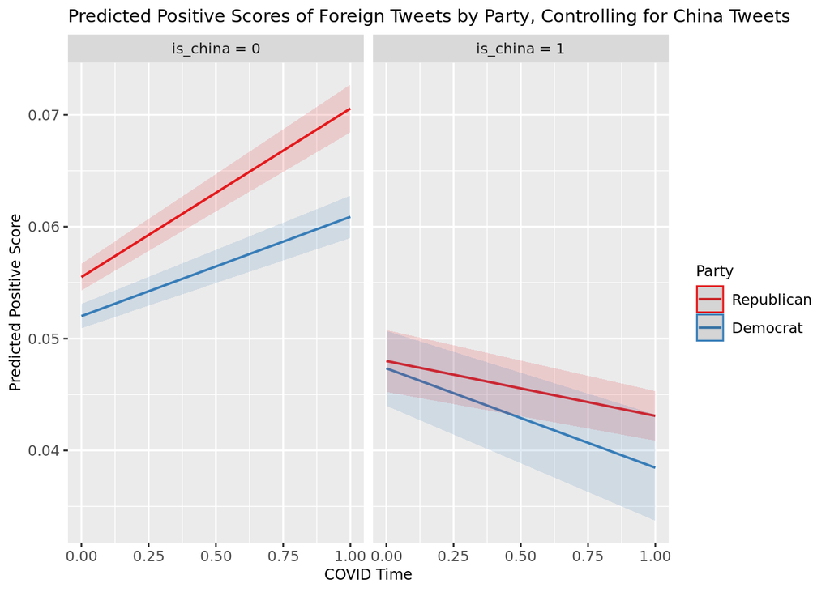

#### Re-Run Results of Model 4b, Controlling for China Tweets

```
##
## Call:
## lm(formula = negative_score_2 ~ is_covid + is_china + party +
##     is_covid * is_china * party + gender + age, data = tweets,
##     subset = is_foreign == 1)
##
## Residuals:
##      Min       1Q   Median       3Q      Max
## -0.09986 -0.05914 -0.02336  0.03996  0.92966
##
## Coefficients:
##                                       Estimate  Std. Error t value
## (Intercept)                         0.05045392  0.00216305  23.325
## is_covid                           -0.00588510  0.00117649  -5.002
## is_china                            0.00022979  0.00194872   0.118
## partyIndependent                    0.01707000  0.00426833   3.999
## partyRepublican                    -0.01870944  0.00087791 -21.311
## genderMale                          0.00551349  0.00085586   6.442
## age                                 0.00019425  0.00003073   6.321
## is_covid:is_china                   0.03303614  0.00345094   9.573
## is_covid:partyIndependent          -0.01408535  0.00963906  -1.461
## is_covid:partyRepublican           -0.00075955  0.00180227  -0.421
## is_china:partyIndependent           0.00900573  0.01728426   0.521
## is_china:partyRepublican            0.00925541  0.00257161   3.599
## is_covid:is_china:partyIndependent -0.04811972  0.03425450  -1.405
## is_covid:is_china:partyRepublican  -0.01224560  0.00420658  -2.911
##                                                Pr(>|t|)
## (Intercept)                        < 0.0000000000000002 ***
## is_covid                                 0.000000568631 ***
## is_china                                        0.90613
## partyIndependent                         0.000063644047 ***
## partyRepublican                    < 0.0000000000000002 ***
## genderMale                               0.000000000119 ***
## age                                      0.000000000262 ***
## is_covid:is_china                  < 0.0000000000000002 ***
## is_covid:partyIndependent                       0.14395
## is_covid:partyRepublican                        0.67344
## is_china:partyIndependent                       0.60234
## is_china:partyRepublican                        0.00032 ***
## is_covid:is_china:partyIndependent              0.16010
## is_covid:is_china:partyRepublican               0.00360 **
## ---
## Signif. codes:  0 '***' 0.001 '**' 0.01 '*' 0.05 '.' 0.1 ' ' 1
##
## Residual standard error: 0.07448 on 48836 degrees of freedom
## Multiple R-squared:  0.02285,    Adjusted R-squared:  0.02259
## F-statistic: 87.84 on 13 and 48836 DF,  p-value: < 0.00000000000000022
```

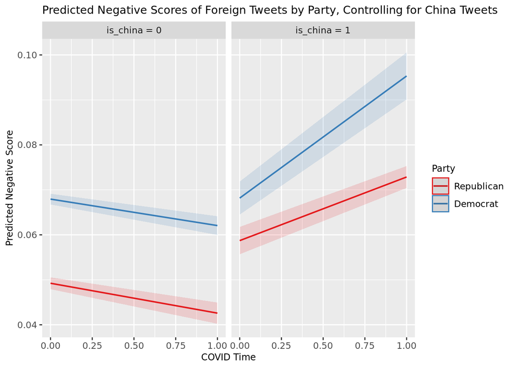